# Which Farmers Are More Productive?

- Show All Code
- Hide All Code
- View Source

Discovering Unobserved Heterogeneity Through Farm Data

Author

Dr Clemens Jarnach

Published

February 1, 2027

**Load packages**

```r
library(tidyverse)
library(plm)
library(knitr)
library(RColorBrewer)

# Colour palette (Oxford blue + accents)
pal_farms <- brewer.pal(5, "Set2")
```

## Step 1 — Set the Scene

> **You are economists hired by a Ministry of Agriculture.**

You have been given data on **five farms**. Your task is to answer one policy question:

> **Does increasing the number of workers raise farm productivity (output)?**

Keep it simple for now: *more workers → more output … right?*

## Step 2 — The Cross-Sectional Evidence

Below is a snapshot of the five farms in a single year.

**Generate cross-sectional data**

```r
set.seed(42)

# Unobserved farm quality (alpha_i) — higher-quality farms also hire more workers
quality <- c(75, 70, 63, 52, 35)        # unobserved: A is best, E is worst
farms   <- LETTERS[1:5]
labour_cs <- c(10, 8, 6, 4, 2)          # correlated with quality!

true_beta <- 2.5                          # true effect of one extra worker

# Output = quality + beta * labour + small noise
set.seed(42)
output_cs <- quality + true_beta * labour_cs + rnorm(5, 0, 1.5)
output_cs <- round(output_cs)

df_cs <- tibble(
  Farm   = farms,
  Labour = labour_cs,
  Output = output_cs
)
```

**Display table**

```r
kable(
  df_cs,
  col.names = c("Farm", "Labour (workers)", "Output (tonnes)"),
  align = "ccc",
  caption = "Table 1 — Cross-sectional snapshot (Year 2)"
)
```

Table 1 — Cross-sectional snapshot (Year 2)

| Farm | Labour (workers) | Output (tonnes) |
| --- | --- | --- |
| A | 10 | 102 |
| B | 8 | 89 |
| C | 6 | 79 |
| D | 4 | 63 |
| E | 2 | 41 |

**Plot cross-sectional relationship**

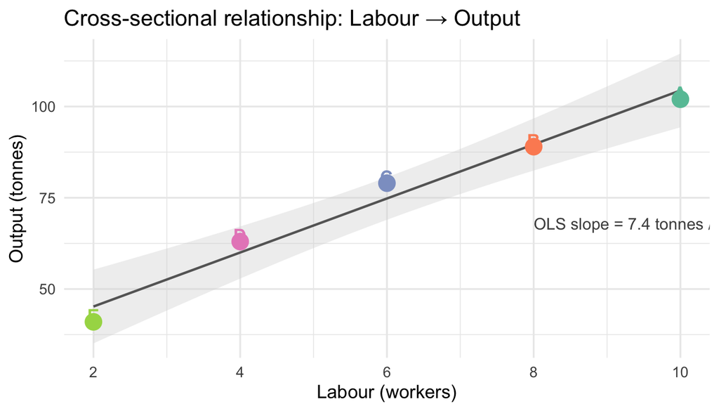

Figure 1 — Pooled OLS fit across farms (cross-section)

```r
ols_cs <- lm(Output ~ Labour, data = df_cs)
beta_cs <- round(coef(ols_cs)["Labour"], 2)

ggplot(df_cs, aes(x = Labour, y = Output, colour = Farm, label = Farm)) +
  geom_smooth(aes(group = 1), method = "lm", se = TRUE,
              colour = "grey40", fill = "grey85", linewidth = 0.8) +
  geom_point(size = 5) +
  geom_text(nudge_y = 1.8, fontface = "bold", size = 4.5) +
  scale_colour_brewer(palette = "Set2") +
  annotate("text", x = 8, y = 68,
           label = paste0("OLS slope = ", beta_cs, " tonnes / worker"),
           colour = "grey30", size = 4, hjust = 0) +
  labs(x = "Labour (workers)", y = "Output (tonnes)",
       title = "Cross-sectional relationship: Labour → Output") +
  theme_minimal(base_size = 13) +
  theme(legend.position = "none")
```

**TipDiscussion — What relationship do you see?**

- The slope is **strongly positive**: roughly 7.4 extra tonnes per additional worker.
- A naïve reading suggests labour is highly productive.
- **Policy temptation:** subsidise hiring to boost output.

**But wait — should we trust this number?**

## Step 3 — Introducing Doubt

**CautionThink before you answer**

> “Are all farms equally good, independent of how many workers they hire?”

Take 30 seconds to discuss with your neighbour. What might be driving the pattern in Figure 1?

**Reveal: unobserved soil quality**

```r
df_cs_full <- df_cs |>
  mutate(Quality = quality,
         Quality_label = c("Very high", "High", "Medium", "Low", "Very low"))

kable(
  df_cs_full |> select(Farm, Labour, Quality_label, Output),
  col.names = c("Farm", "Labour (workers)", "Soil Quality (hidden!)", "Output (tonnes)"),
  align = "cccc",
  caption = "Table 2 — The hidden variable revealed"
)
```

Table 2 — The hidden variable revealed

| Farm | Labour (workers) | Soil Quality (hidden!) | Output (tonnes) |
| --- | --- | --- | --- |
| A | 10 | Very high | 102 |
| B | 8 | High | 89 |
| C | 6 | Medium | 79 |
| D | 4 | Low | 63 |
| E | 2 | Very low | 41 |

**Plot confounding structure**

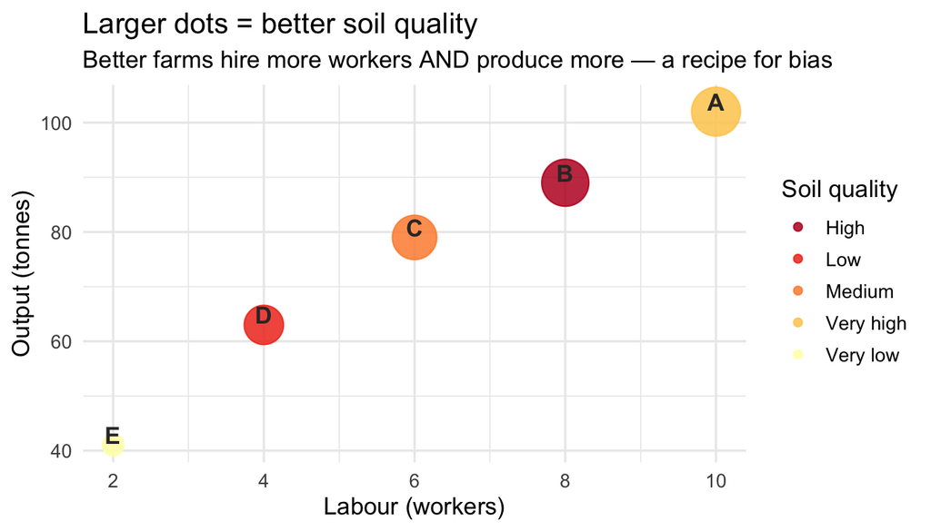

Figure 2 — Labour is correlated with unobserved soil quality

```r
ggplot(df_cs_full, aes(x = Labour, y = Output, colour = Quality_label, label = Farm)) +
  geom_point(aes(size = Quality), alpha = 0.85) +
  geom_text(nudge_y = 1.8, fontface = "bold", size = 4.5, colour = "grey20") +
  scale_colour_brewer(palette = "YlOrRd", direction = -1,
                      name = "Soil quality") +
  scale_size_continuous(range = c(5, 12), guide = "none") +
  labs(x = "Labour (workers)", y = "Output (tonnes)",
       title = "Larger dots = better soil quality",
       subtitle = "Better farms hire more workers AND produce more — a recipe for bias") +
  theme_minimal(base_size = 13) +
  theme(legend.position = "right")
```

**WarningReveal — The omitted variable bias**

The OLS estimate of **7.4** tonnes per worker is **upward biased** because:

$$y_{it} = \alpha + \beta_{\text{OLS}}\, x_{it} + \varepsilon_{it}$$

…but the true model is:

$$y_{it} = \alpha_i + \beta_{\text{true}}\, x_{it} + u_{it}$$

where $\alpha_i$ = soil quality (unobserved). Since better farms hire more workers, $\text{Cov}(x_{it},\, \alpha_i) > 0$, so $\hat\beta_{\text{OLS}} > \beta_{\text{true}}$.

## Step 4 — The Panel Data Reveal

Now we track the **same farms over two years**. Each farm changed its workforce between years.

**Generate panel data (5 farms × 2 years)**

```r
set.seed(42)

# Labour levels in year 1 and year 2 (within-farm changes are small)
labour_y1 <- c(6, 5, 4, 3, 1)
labour_y2 <- labour_cs          # same as cross-section year 2

output_y1 <- quality + true_beta * labour_y1 + rnorm(5, 0, 1)
output_y1 <- round(output_y1)

df_panel <- tibble(
  Farm   = rep(farms, 2),
  Year   = rep(c("Year 1", "Year 2"), each = 5),
  Labour = c(labour_y1, labour_y2),
  Output = c(output_y1, output_cs)
)

# Wide format for within-farm differences
df_wide <- df_panel |>
  pivot_wider(names_from = Year, values_from = c(Labour, Output)) |>
  mutate(
    Delta_Labour = `Labour_Year 2` - `Labour_Year 1`,
    Delta_Output = `Output_Year 2` - `Output_Year 1`,
    Within_beta  = round(Delta_Output / Delta_Labour, 2)
  )
```

**Display panel table**

```r
kable(
  df_panel |> arrange(Farm, Year),
  col.names = c("Farm", "Year", "Labour (workers)", "Output (tonnes)"),
  align = "cccc",
  caption = "Table 3 — Panel data: same farms observed over two years"
)
```

Table 3 — Panel data: same farms observed over two years

| Farm | Year | Labour (workers) | Output (tonnes) |
| --- | --- | --- | --- |
| A | Year 1 | 6 | 91 |
| A | Year 2 | 10 | 102 |
| B | Year 1 | 5 | 82 |
| B | Year 2 | 8 | 89 |
| C | Year 1 | 4 | 73 |
| C | Year 2 | 6 | 79 |
| D | Year 1 | 3 | 60 |
| D | Year 2 | 4 | 63 |
| E | Year 1 | 1 | 38 |
| E | Year 2 | 2 | 41 |

**Plot within-farm trends**

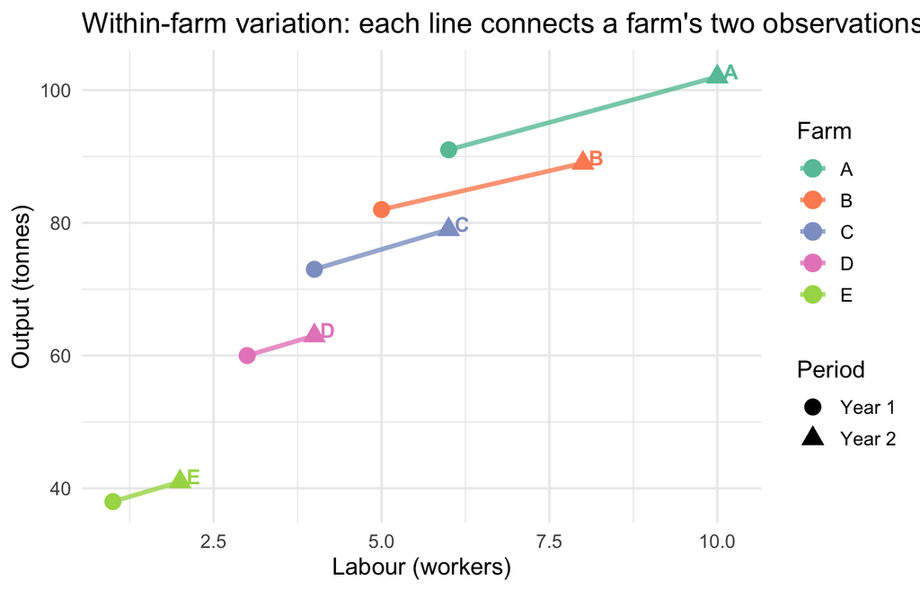

Figure 3 — Within-farm changes: each line is one farm over time

```r
ggplot(df_panel, aes(x = Labour, y = Output,
                     colour = Farm, group = Farm, label = Farm)) +
  geom_line(linewidth = 1.2, alpha = 0.8) +
  geom_point(aes(shape = Year), size = 4) +
  geom_text(data = df_panel |> filter(Year == "Year 2"),
            nudge_x = 0.2, nudge_y = 0.8,
            fontface = "bold", size = 4) +
  scale_colour_brewer(palette = "Set2") +
  scale_shape_manual(values = c("Year 1" = 16, "Year 2" = 17)) +
  labs(x = "Labour (workers)", y = "Output (tonnes)",
       title = "Within-farm variation: each line connects a farm's two observations",
       colour = "Farm", shape = "Period") +
  theme_minimal(base_size = 13)
```

**Within-farm differences table**

```r
kable(
  df_wide |>
    select(Farm,
           "Labour (Y1)" = `Labour_Year 1`,
           "Labour (Y2)" = `Labour_Year 2`,
           "Output (Y1)" = `Output_Year 1`,
           "Output (Y2)" = `Output_Year 2`,
           "ΔLabour" = Delta_Labour,
           "ΔOutput" = Delta_Output,
           "ΔOutput/ΔLabour" = Within_beta),
  align = "cccccccc",
  caption = "Table 4 — Within-farm changes between Year 1 and Year 2"
)
```

Table 4 — Within-farm changes between Year 1 and Year 2

| Farm | Labour (Y1) | Labour (Y2) | Output (Y1) | Output (Y2) | ΔLabour | ΔOutput | ΔOutput/ΔLabour |
| --- | --- | --- | --- | --- | --- | --- | --- |
| A | 6 | 10 | 91 | 102 | 4 | 11 | 2.75 |
| B | 5 | 8 | 82 | 89 | 3 | 7 | 2.33 |
| C | 4 | 6 | 73 | 79 | 2 | 6 | 3.00 |
| D | 3 | 4 | 60 | 63 | 1 | 3 | 3.00 |
| E | 1 | 2 | 38 | 41 | 1 | 3 | 3.00 |

**TipDiscussion — What changed?**

Compare the **within-farm slope** (Table 4) to the **cross-sectional OLS slope** from Figure 1.

- The within-farm estimates are **much smaller** — close to the true $\beta = 2.5$.
- The cross-sectional estimate of **7.4** was inflated because better farms (high $\alpha_i$) also hire more workers.
- When we look *within* a farm across time, $\alpha_i$ is held constant — quality does not change between Year 1 and Year 2 for the same farm.

> “The farm does not change its soil between years. Only its labour does.”

## Step 5 — The Insight: Mundlak (1961)

> *What you just discovered is exactly the problem identified by Yair Mundlak in 1961.”*

Map the story onto the formal model:

| Story element | Notation |
| --- | --- |
| Farm output | $y_{it}$ |
| Labour input | $x_{it}$ |
| Soil quality / skill | $\alpha_i$ |
| Year | $t$ |
| Farm | $i$ |

**The key message:**

> *“We were confusing differences **between farms** with changes **within farms**.”*

Between-farm variation is contaminated by $\alpha_i$. Within-farm variation over time is not — because the farm’s soil quality is the same in both years.

## Step 6 — From Intuition to Fixed Effects

**Run and compare OLS vs FE**

```r
# Pooled OLS (ignores farm identity)
mod_ols <- lm(Output ~ Labour, data = df_panel)

# Fixed effects (within estimator via plm)
pdata   <- pdata.frame(df_panel, index = c("Farm", "Year"))
mod_fe  <- plm(Output ~ Labour, data = pdata, model = "within")

beta_ols <- round(coef(mod_ols)["Labour"], 3)
beta_fe  <- round(coef(mod_fe)["Labour"], 3)
```

**Display regression comparison**

```r
tibble(
  Estimator   = c("Pooled OLS", "Fixed Effects (within)"),
  `β̂ (Labour)` = c(beta_ols, beta_fe),
  `True β`    = c(true_beta, true_beta),
  Bias        = c(round(beta_ols - true_beta, 3),
                  round(beta_fe  - true_beta, 3)),
  `Variation used` = c("Between + within farms", "Within farms only")
) |>
  kable(align = "lcccc",
        caption = "Table 5 — Pooled OLS vs Fixed Effects")
```

Table 5 — Pooled OLS vs Fixed Effects

| Estimator | β̂ (Labour) | True β | Bias | Variation used |
| --- | --- | --- | --- | --- |
| Pooled OLS | 7.291 | 2.5 | 4.791 | Between + within farms |
| Fixed Effects (within) | 2.677 | 2.5 | 0.177 | Within farms only |

**Plot both regression fits**

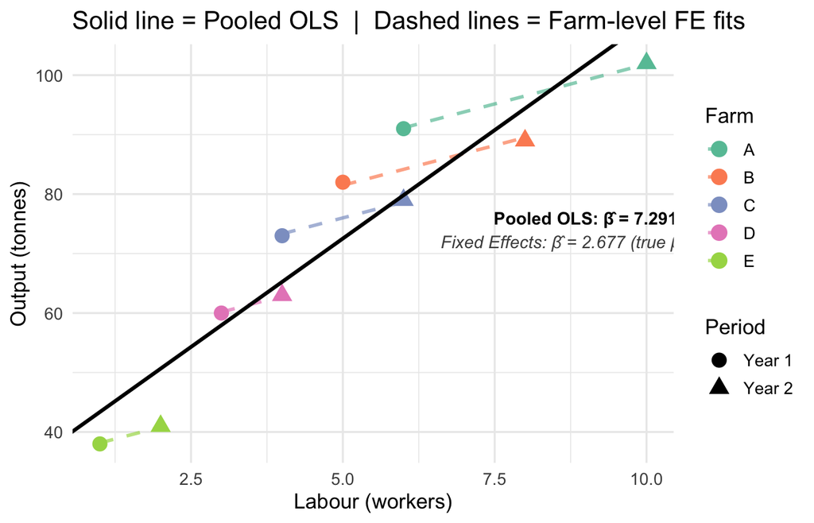

Figure 4 — OLS vs within-farm (FE) estimates on the panel data

```r
# Fitted values from FE (add farm means back in for plotting)
df_panel <- df_panel |>
  group_by(Farm) |>
  mutate(
    Labour_dm = Labour - mean(Labour),
    Output_dm = Output - mean(Output),
    Farm_mean_Labour = mean(Labour),
    Farm_mean_Output = mean(Output)
  ) |>
  ungroup()

ggplot(df_panel, aes(x = Labour, y = Output, colour = Farm, group = Farm)) +
  # Farm-level parallel FE lines
  geom_line(aes(y = Farm_mean_Output + beta_fe * (Labour - Farm_mean_Labour)),
            linewidth = 1, linetype = "dashed", alpha = 0.7) +
  # Observed points
  geom_point(aes(shape = Year), size = 4) +
  # Pooled OLS line
  geom_abline(intercept = coef(mod_ols)[1], slope = coef(mod_ols)[2],
              colour = "black", linewidth = 1.1, linetype = "solid") +
  scale_colour_brewer(palette = "Set2") +
  scale_shape_manual(values = c("Year 1" = 16, "Year 2" = 17)) +
  annotate("text", x = 9, y = 76,
           label = paste0("Pooled OLS: β̂ = ", beta_ols),
           colour = "black", fontface = "bold", size = 3.8) +
  annotate("text", x = 9, y = 72,
           label = paste0("Fixed Effects: β̂ = ", beta_fe,
                          " (true β = ", true_beta, ")"),
           colour = "grey30", fontface = "italic", size = 3.8) +
  labs(x = "Labour (workers)", y = "Output (tonnes)",
       title = "Solid line = Pooled OLS  |  Dashed lines = Farm-level FE fits",
       colour = "Farm", shape = "Period") +
  theme_minimal(base_size = 13)
```

**NoteReading the plot**

The **solid black line** is the pooled OLS regression line fitted on all 10 observations (5 farms × 2 years) combined, as if they were independent cross-sectional data points. It ignores farm identity entirely — every observation is treated as a separate, unrelated data point. The slope is therefore driven by **both** between-farm and within-farm variation mixed together. Because high-quality farms have both more labour and more output, the between-farm signal dominates and inflates the slope upward.

The **dashed coloured lines**, by contrast, are the farm-level FE fits — parallel lines with the within slope ($\hat\beta_{\text{FE}}$), one per farm, each anchored to that farm’s own mean. They use only within-farm variation over time, which is why their slope is much flatter and closer to the true $\beta$.

The contrast between the steep black line and the shallow dashed lines is the visual payoff of the whole exercise: **same data, very different estimates** — because of what variation each estimator uses.

**ImportantPolicy question — What mistake would we make?**

**If we used the cross-sectional (OLS) estimate of 7.291 tonnes per worker:**

- We would **over-subsidise labour** — expecting large output gains from hiring.
- We would **misattribute productivity** to labour inputs, when it is really driven by underlying farm quality ($\alpha_i$).
- The government would transfer resources to farms expecting gains that will not materialise.

**The fixed effects estimate of 2.677 tonnes per worker** — much closer to the true $\beta = 2.5$ — gives the correct policy signal: labour has a real but **much more modest** effect on output.

> *“Fixed effects models do exactly what you just did informally: they hold each unit constant and look only at within-unit variation over time.”*